# Prediction of Workout Performance Based off Previous Performance

Emi N. Harry

July 25, 2016

## Executive Summary

The data from the accelometers of 6 participants was preprocessed and fitted to 3 models using random forest (rf), regularized random forest (RRF) and stochastic gradient boosting (gbm). The first model fit done with “rf” has 99.75% accuracy, the second model fit done with “gbm” has 99.75% accuracy and the third model fit done with “RRF” has 100% accuracy. When all the 3 models are stacked, the final model is fitted using “gbm” and it has 100% accuracy.

## Introduction

Using devices such as Jawbone Up, Nike FuelBand, and Fitbit it is now possible to collect a large amount of data about personal activity relatively inexpensively. These type of devices are part of the quantified self movement - a group of enthusiasts who take measurements about themselves regularly to improve their health, to find patterns in their behavior, or because they are tech geeks. One thing that people regularly do is quantify how much of a particular activity they do, but they rarely quantify how well they do it. In this project, the goal is to use data from accelerometers on the belt, forearm, arm, and dumbell of 6 participant to predict the manner in which they did the exercises. They were asked to perform barbell lifts correctly and incorrectly in 5 different ways. More information is available from the website here: http://groupware.les.inf.puc-rio.br/har (see the section on the Weight Lifting Exercise Dataset).

## Getting and Cleaning The Data

The first step is to load the data sets into R.

```r
require(data.table)
Build <- fread("https://d396qusza40orc.cloudfront.net/predmachlearn/pml-training.csv")
validate <- fread("https://d396qusza40orc.cloudfront.net/predmachlearn/pml-testing.csv")
str(Build)
```

```
Classes 'data.table' and 'data.frame':  19622 obs. of  160 variables:
 $ V1                      : chr  "1" "2" "3" "4" ...
 $ user_name               : chr  "carlitos" "carlitos" "carlitos" "carlitos" ...
 $ raw_timestamp_part_1    : int  1323084231 1323084231 1323084231 1323084232 1323084232 1323084232 1323084232 1323084232 1323084232 1323084232 ...
 $ raw_timestamp_part_2    : int  788290 808298 820366 120339 196328 304277 368296 440390 484323 484434 ...
 $ cvtd_timestamp          : chr  "05/12/2011 11:23" "05/12/2011 11:23" "05/12/2011 11:23" "05/12/2011 11:23" ...
 $ new_window              : chr  "no" "no" "no" "no" ...
 $ num_window              : int  11 11 11 12 12 12 12 12 12 12 ...
 $ roll_belt               : num  1.41 1.41 1.42 1.48 1.48 1.45 1.42 1.42 1.43 1.45 ...
 $ pitch_belt              : num  8.07 8.07 8.07 8.05 8.07 8.06 8.09 8.13 8.16 8.17 ...
 $ yaw_belt                : num  -94.4 -94.4 -94.4 -94.4 -94.4 -94.4 -94.4 -94.4 -94.4 -94.4 ...
 $ total_accel_belt        : int  3 3 3 3 3 3 3 3 3 3 ...
 $ kurtosis_roll_belt      : chr  "" "" "" "" ...
 $ kurtosis_picth_belt     : chr  "" "" "" "" ...
 $ kurtosis_yaw_belt       : chr  "" "" "" "" ...
```

[output cut: 87 more lines]

Remove the first column for both data sets as it serves no purpose and convert the data sets to dataframes.

```r
Build <- data.frame(Build)
Build <- Build[, -1]
Build$classe <- as.factor(Build$classe)

validate <- data.frame(validate)
validate <- validate[, -1]
```

Process for the Build data set to observe near zero predictors.

```r
require(caret)
nzv <- nearZeroVar(Build, saveMetrics = TRUE)
nzvVal <- nearZeroVar(validate, saveMetrics = TRUE)
```

Next check to see which variables with zero variance

```r
nzv[nzv[,"zeroVar"] > 0, ]
```

```
[1] freqRatio     percentUnique zeroVar       nzv
<0 rows> (or 0-length row.names)
```

```r
nzvVal[nzv[,"zeroVar"] > 0, ]
```

```
[1] freqRatio     percentUnique zeroVar       nzv
<0 rows> (or 0-length row.names)
```

There are clearly no variables(predictors) with zero variance so the next step is to identify all variables with near zero variance.

```r
nzv[nzv[,"zeroVar"] + nzv[,"nzv"] > 0, ]
```

```
                         freqRatio percentUnique zeroVar  nzv
new_window                47.33005    0.01019264   FALSE TRUE
kurtosis_roll_belt      1921.60000    2.02323922   FALSE TRUE
kurtosis_picth_belt      600.50000    1.61553358   FALSE TRUE
kurtosis_yaw_belt         47.33005    0.01019264   FALSE TRUE
skewness_roll_belt      2135.11111    2.01304658   FALSE TRUE
skewness_roll_belt.1     600.50000    1.72255631   FALSE TRUE
skewness_yaw_belt         47.33005    0.01019264   FALSE TRUE
max_yaw_belt             640.53333    0.34654979   FALSE TRUE
min_yaw_belt             640.53333    0.34654979   FALSE TRUE
amplitude_yaw_belt        50.04167    0.02038528   FALSE TRUE
avg_roll_arm              77.00000    1.68178575   FALSE TRUE
stddev_roll_arm           77.00000    1.68178575   FALSE TRUE
var_roll_arm              77.00000    1.68178575   FALSE TRUE
avg_pitch_arm             77.00000    1.68178575   FALSE TRUE
stddev_pitch_arm          77.00000    1.68178575   FALSE TRUE
var_pitch_arm             77.00000    1.68178575   FALSE TRUE
avg_yaw_arm               77.00000    1.68178575   FALSE TRUE
stddev_yaw_arm            80.00000    1.66649679   FALSE TRUE
var_yaw_arm               80.00000    1.66649679   FALSE TRUE
kurtosis_roll_arm        246.35897    1.68178575   FALSE TRUE
kurtosis_picth_arm       240.20000    1.67159311   FALSE TRUE
kurtosis_yaw_arm        1746.90909    2.01304658   FALSE TRUE
skewness_roll_arm        249.55844    1.68688207   FALSE TRUE
skewness_pitch_arm       240.20000    1.67159311   FALSE TRUE
skewness_yaw_arm        1746.90909    2.01304658   FALSE TRUE
max_roll_arm              25.66667    1.47793293   FALSE TRUE
min_roll_arm              19.25000    1.41677709   FALSE TRUE
min_pitch_arm             19.25000    1.47793293   FALSE TRUE
amplitude_roll_arm        25.66667    1.55947406   FALSE TRUE
amplitude_pitch_arm       20.00000    1.49831821   FALSE TRUE
kurtosis_roll_dumbbell  3843.20000    2.02833554   FALSE TRUE
kurtosis_picth_dumbbell 9608.00000    2.04362450   FALSE TRUE
kurtosis_yaw_dumbbell     47.33005    0.01019264   FALSE TRUE
skewness_roll_dumbbell  4804.00000    2.04362450   FALSE TRUE
skewness_pitch_dumbbell 9608.00000    2.04872082   FALSE TRUE
skewness_yaw_dumbbell     47.33005    0.01019264   FALSE TRUE
max_yaw_dumbbell         960.80000    0.37203139   FALSE TRUE
min_yaw_dumbbell         960.80000    0.37203139   FALSE TRUE
amplitude_yaw_dumbbell    47.92020    0.01528896   FALSE TRUE
kurtosis_roll_forearm    228.76190    1.64101519   FALSE TRUE
kurtosis_picth_forearm   226.07059    1.64611151   FALSE TRUE
kurtosis_yaw_forearm      47.33005    0.01019264   FALSE TRUE
skewness_roll_forearm    231.51807    1.64611151   FALSE TRUE
skewness_pitch_forearm   226.07059    1.62572623   FALSE TRUE
skewness_yaw_forearm      47.33005    0.01019264   FALSE TRUE
max_roll_forearm          27.66667    1.38110284   FALSE TRUE
max_yaw_forearm          228.76190    0.22933442   FALSE TRUE
min_roll_forearm          27.66667    1.37091020   FALSE TRUE
min_yaw_forearm          228.76190    0.22933442   FALSE TRUE
amplitude_roll_forearm    20.75000    1.49322189   FALSE TRUE
amplitude_yaw_forearm     59.67702    0.01528896   FALSE TRUE
avg_roll_forearm          27.66667    1.64101519   FALSE TRUE
stddev_roll_forearm       87.00000    1.63082255   FALSE TRUE
var_roll_forearm          87.00000    1.63082255   FALSE TRUE
avg_pitch_forearm         83.00000    1.65120783   FALSE TRUE
stddev_pitch_forearm      41.50000    1.64611151   FALSE TRUE
var_pitch_forearm         83.00000    1.65120783   FALSE TRUE
avg_yaw_forearm           83.00000    1.65120783   FALSE TRUE
stddev_yaw_forearm        85.00000    1.64101519   FALSE TRUE
var_yaw_forearm           85.00000    1.64101519   FALSE TRUE
```

```r
nzvVal[nzv[,"zeroVar"] + nzv[,"nzv"] > 0, ]
```

```
                        freqRatio percentUnique zeroVar  nzv
new_window                      0             5    TRUE TRUE
kurtosis_roll_belt              0             5    TRUE TRUE
kurtosis_picth_belt             0             5    TRUE TRUE
kurtosis_yaw_belt               0             5    TRUE TRUE
skewness_roll_belt              0             5    TRUE TRUE
skewness_roll_belt.1            0             5    TRUE TRUE
skewness_yaw_belt               0             5    TRUE TRUE
max_yaw_belt                    0             5    TRUE TRUE
min_yaw_belt                    0             5    TRUE TRUE
amplitude_yaw_belt              0             5    TRUE TRUE
avg_roll_arm                    0             0    TRUE TRUE
stddev_roll_arm                 0             0    TRUE TRUE
var_roll_arm                    0             0    TRUE TRUE
avg_pitch_arm                   0             0    TRUE TRUE
stddev_pitch_arm                0             0    TRUE TRUE
var_pitch_arm                   0             0    TRUE TRUE
avg_yaw_arm                     0             0    TRUE TRUE
stddev_yaw_arm                  0             0    TRUE TRUE
var_yaw_arm                     0             0    TRUE TRUE
kurtosis_roll_arm               0             5    TRUE TRUE
kurtosis_picth_arm              0             5    TRUE TRUE
kurtosis_yaw_arm                0             5    TRUE TRUE
skewness_roll_arm               0             5    TRUE TRUE
skewness_pitch_arm              0             5    TRUE TRUE
skewness_yaw_arm                0             5    TRUE TRUE
max_roll_arm                    0             0    TRUE TRUE
min_roll_arm                    0             0    TRUE TRUE
min_pitch_arm                   0             0    TRUE TRUE
amplitude_roll_arm              0             0    TRUE TRUE
amplitude_pitch_arm             0             0    TRUE TRUE
kurtosis_roll_dumbbell          0             5    TRUE TRUE
kurtosis_picth_dumbbell         0             5    TRUE TRUE
kurtosis_yaw_dumbbell           0             5    TRUE TRUE
skewness_roll_dumbbell          0             5    TRUE TRUE
skewness_pitch_dumbbell         0             5    TRUE TRUE
skewness_yaw_dumbbell           0             5    TRUE TRUE
max_yaw_dumbbell                0             5    TRUE TRUE
min_yaw_dumbbell                0             5    TRUE TRUE
amplitude_yaw_dumbbell          0             5    TRUE TRUE
kurtosis_roll_forearm           0             5    TRUE TRUE
kurtosis_picth_forearm          0             5    TRUE TRUE
kurtosis_yaw_forearm            0             5    TRUE TRUE
skewness_roll_forearm           0             5    TRUE TRUE
skewness_pitch_forearm          0             5    TRUE TRUE
skewness_yaw_forearm            0             5    TRUE TRUE
max_roll_forearm                0             0    TRUE TRUE
max_yaw_forearm                 0             5    TRUE TRUE
min_roll_forearm                0             0    TRUE TRUE
min_yaw_forearm                 0             5    TRUE TRUE
amplitude_roll_forearm          0             0    TRUE TRUE
amplitude_yaw_forearm           0             5    TRUE TRUE
avg_roll_forearm                0             0    TRUE TRUE
stddev_roll_forearm             0             0    TRUE TRUE
var_roll_forearm                0             0    TRUE TRUE
avg_pitch_forearm               0             0    TRUE TRUE
stddev_pitch_forearm            0             0    TRUE TRUE
var_pitch_forearm               0             0    TRUE TRUE
avg_yaw_forearm                 0             0    TRUE TRUE
stddev_yaw_forearm              0             0    TRUE TRUE
var_yaw_forearm                 0             0    TRUE TRUE
```

```r
letgo <- nzv[nzv[,"zeroVar"] + nzv[,"nzv"] > 0, ]
letgo1 <- nzvVal[nzv[,"zeroVar"] + nzv[,"nzv"] > 0, ]
```

```r
letgoNames <- c(rownames(letgo))
newBuild = Build[,!(names(Build) %in% letgoNames)]

letgoNames1 <- c(rownames(letgo1))
newvalidate = validate[,!(names(validate) %in% letgoNames1)]
```

### Visualization of NA Pattern

Plotting a pattern of the missing data will help in deciding if to delete all rows with missing data or if we and replace them with aggregates.

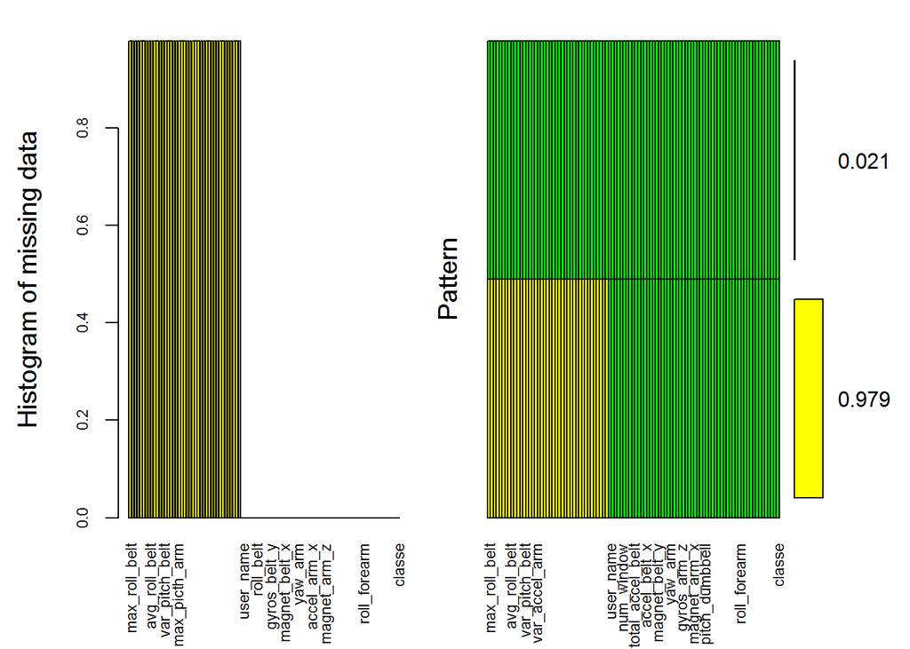

```
 Variables sorted by number of missings:
                 Variable     Count
            max_roll_belt 0.9793089
           max_picth_belt 0.9793089
            min_roll_belt 0.9793089
           min_pitch_belt 0.9793089
      amplitude_roll_belt 0.9793089
     amplitude_pitch_belt 0.9793089
     var_total_accel_belt 0.9793089
            avg_roll_belt 0.9793089
         stddev_roll_belt 0.9793089
            var_roll_belt 0.9793089
           avg_pitch_belt 0.9793089
        stddev_pitch_belt 0.9793089
           var_pitch_belt 0.9793089
             avg_yaw_belt 0.9793089
          stddev_yaw_belt 0.9793089
             var_yaw_belt 0.9793089
            var_accel_arm 0.9793089
            max_picth_arm 0.9793089
              max_yaw_arm 0.9793089
              min_yaw_arm 0.9793089
        amplitude_yaw_arm 0.9793089
        max_roll_dumbbell 0.9793089
       max_picth_dumbbell 0.9793089
        min_roll_dumbbell 0.9793089
       min_pitch_dumbbell 0.9793089
  amplitude_roll_dumbbell 0.9793089
 amplitude_pitch_dumbbell 0.9793089
       var_accel_dumbbell 0.9793089
        avg_roll_dumbbell 0.9793089
     stddev_roll_dumbbell 0.9793089
        var_roll_dumbbell 0.9793089
       avg_pitch_dumbbell 0.9793089
    stddev_pitch_dumbbell 0.9793089
       var_pitch_dumbbell 0.9793089
         avg_yaw_dumbbell 0.9793089
      stddev_yaw_dumbbell 0.9793089
         var_yaw_dumbbell 0.9793089
        max_picth_forearm 0.9793089
```

[output cut: 46 more lines]

```
        magnet_dumbbell_z 0.0000000
             roll_forearm 0.0000000
            pitch_forearm 0.0000000
              yaw_forearm 0.0000000
      total_accel_forearm 0.0000000
          gyros_forearm_x 0.0000000
          gyros_forearm_y 0.0000000
          gyros_forearm_z 0.0000000
          accel_forearm_x 0.0000000
          accel_forearm_y 0.0000000
          accel_forearm_z 0.0000000
         magnet_forearm_x 0.0000000
         magnet_forearm_y 0.0000000
         magnet_forearm_z 0.0000000
                   classe 0.0000000
```

```r
require(VIM)
aggr_plot <- aggr(newBuild, col=c('green','yellow'), numbers=TRUE, sortVars=TRUE,
                  labels=names(newBuild), cex.axis=.7, gap=3,
                  ylab=c("Histogram of missing data","Pattern"))
```

### Preprocessing of the Data Sets

The data sets are preprocessed to ensure there are no NA values. The original training set which is save as building will be used to create a new training and testing set, while the original testing set will be used for the cross validation.

```r
require(RANN)
preProcValues <- preProcess(newBuild, method = c("center", "scale", "knnImpute", "nzv"), na.remove = T, verbose = F)
building <- predict(preProcValues, newBuild)
building$classe <- Build$classe
validation <- predict(preProcValues, newvalidate)
```

Partition the Build data set in order to create training and testing data sets.

```r
inTrain <- createDataPartition(y=building$classe, p=0.7, list=FALSE)
training <- building[inTrain,]; testing <- building[-inTrain,]
```

## Prediction Modelling

In order to get predictions with a high accuracy, the model ensembling method is going to be used. 3 models will be fitted using random forest and boosting.

```r
require(gbm); require(randomForest);
set.seed(4400)
mod1 <- train(classe ~.,method="rf",data=training, metric = "Accuracy",
              trControl = trainControl(method = "cv"), number=5)
mod2 <- train(classe ~.,method="gbm",data=training)
mod3 <- train(classe ~.,method="RRF",data=training)
```

### Predicting on testing data

The individual predictions are carried out.

```r
pred1 <- predict(mod1, testing); pred2 <- predict(mod2, testing); pred3 <- predict(mod3, testing)
```

### Model Ensembling

Next I stack the prediction models and fit using boosting to get a new model.

```r
predDF <- data.frame(pred1,pred2,pred3,classe=testing$classe)
set.seed(23465)
combModFit <- train(classe ~.,method="gbm",data=predDF)
combPred <- predict(combModFit,predDF)
```

### Confusion Matrix

The confusion matrix shows their accuracy level

```r
confusionMatrix(pred1, testing$classe)
```

```
Confusion Matrix and Statistics

          Reference
Prediction    A    B    C    D    E
         A 1674    4    1    0    0
         B    0 1135    7    0    0
         C    0    0 1018    3    0
         D    0    0    0  961    0
         E    0    0    0    0 1082

Overall Statistics

               Accuracy : 0.9975
                 95% CI : (0.9958, 0.9986)
    No Information Rate : 0.2845
    P-Value [Acc > NIR] : < 2.2e-16

                  Kappa : 0.9968
 Mcnemar's Test P-Value : NA

Statistics by Class:

                     Class: A Class: B Class: C Class: D Class: E
Sensitivity            1.0000   0.9965   0.9922   0.9969   1.0000
Specificity            0.9988   0.9985   0.9994   1.0000   1.0000
Pos Pred Value         0.9970   0.9939   0.9971   1.0000   1.0000
Neg Pred Value         1.0000   0.9992   0.9984   0.9994   1.0000
Prevalence             0.2845   0.1935   0.1743   0.1638   0.1839
Detection Rate         0.2845   0.1929   0.1730   0.1633   0.1839
Detection Prevalence   0.2853   0.1941   0.1735   0.1633   0.1839
Balanced Accuracy      0.9994   0.9975   0.9958   0.9984   1.0000
```

```r
confusionMatrix(pred2, testing$classe)
```

```
Confusion Matrix and Statistics

          Reference
Prediction    A    B    C    D    E
         A 1674    0    0    0    0
         B    0 1136    0    0    0
         C    0    1 1017    3    0
         D    0    2    9  961    0
         E    0    0    0    0 1082

Overall Statistics

               Accuracy : 0.9975
                 95% CI : (0.9958, 0.9986)
    No Information Rate : 0.2845
    P-Value [Acc > NIR] : < 2.2e-16

                  Kappa : 0.9968
 Mcnemar's Test P-Value : NA

Statistics by Class:

                     Class: A Class: B Class: C Class: D Class: E
Sensitivity            1.0000   0.9974   0.9912   0.9969   1.0000
Specificity            1.0000   1.0000   0.9992   0.9978   1.0000
Pos Pred Value         1.0000   1.0000   0.9961   0.9887   1.0000
Neg Pred Value         1.0000   0.9994   0.9981   0.9994   1.0000
Prevalence             0.2845   0.1935   0.1743   0.1638   0.1839
Detection Rate         0.2845   0.1930   0.1728   0.1633   0.1839
Detection Prevalence   0.2845   0.1930   0.1735   0.1652   0.1839
Balanced Accuracy      1.0000   0.9987   0.9952   0.9973   1.0000
```

```r
confusionMatrix(pred3, testing$classe)
```

```
Confusion Matrix and Statistics

          Reference
Prediction    A    B    C    D    E
         A 1674    0    0    0    0
         B    0 1139    0    0    0
         C    0    0 1026    0    0
         D    0    0    0  964    0
         E    0    0    0    0 1082

Overall Statistics

               Accuracy : 1
                 95% CI : (0.9994, 1)
    No Information Rate : 0.2845
    P-Value [Acc > NIR] : < 2.2e-16

                  Kappa : 1
 Mcnemar's Test P-Value : NA

Statistics by Class:

                     Class: A Class: B Class: C Class: D Class: E
Sensitivity            1.0000   1.0000   1.0000   1.0000   1.0000
Specificity            1.0000   1.0000   1.0000   1.0000   1.0000
Pos Pred Value         1.0000   1.0000   1.0000   1.0000   1.0000
Neg Pred Value         1.0000   1.0000   1.0000   1.0000   1.0000
Prevalence             0.2845   0.1935   0.1743   0.1638   0.1839
Detection Rate         0.2845   0.1935   0.1743   0.1638   0.1839
Detection Prevalence   0.2845   0.1935   0.1743   0.1638   0.1839
Balanced Accuracy      1.0000   1.0000   1.0000   1.0000   1.0000
```

```r
confusionMatrix(combPred, testing$classe)
```

```
Confusion Matrix and Statistics

          Reference
Prediction    A    B    C    D    E
         A 1674    0    0    0    0
         B    0 1139    0    0    0
         C    0    0 1026    0    0
         D    0    0    0  964    0
         E    0    0    0    0 1082

Overall Statistics

               Accuracy : 1
                 95% CI : (0.9994, 1)
    No Information Rate : 0.2845
    P-Value [Acc > NIR] : < 2.2e-16

                  Kappa : 1
 Mcnemar's Test P-Value : NA

Statistics by Class:

                     Class: A Class: B Class: C Class: D Class: E
Sensitivity            1.0000   1.0000   1.0000   1.0000   1.0000
Specificity            1.0000   1.0000   1.0000   1.0000   1.0000
Pos Pred Value         1.0000   1.0000   1.0000   1.0000   1.0000
Neg Pred Value         1.0000   1.0000   1.0000   1.0000   1.0000
Prevalence             0.2845   0.1935   0.1743   0.1638   0.1839
Detection Rate         0.2845   0.1935   0.1743   0.1638   0.1839
Detection Prevalence   0.2845   0.1935   0.1743   0.1638   0.1839
Balanced Accuracy      1.0000   1.0000   1.0000   1.0000   1.0000
```

### Cross Validation

Now the original testing set is being used for the cross validation.

```r
pred1V <- predict(mod1,validation); pred2V <- predict(mod2,validation); pred3V <- predict(mod3,validation)
predVDF <- data.frame(pred1=pred1V,pred2=pred2V,pred3=pred3V)
combPredV <- predict(combModFit,predVDF)
```

## Conclusion

The final predictions are as follows:

```r
combPredV
```

```
 [1] B A B A A E D B A A B C B A E E A B B B
Levels: A B C D E
```